# Classification Part 3: Sensitivity, Specificity, and ROC Curves

2026-10-26

# How to use these notes

This file has the full code for today’s live coding, posted before class.

The code is split into sections. Each section starts with a **CHECKPOINT** chunk. A checkpoint chunk rebuilds everything the section needs from scratch: it loads the packages, loads the data, and redoes the earlier steps. If you hit an error or fall behind, run the most recent checkpoint chunk and you are caught up. You do not need to fix the earlier error first.

**New today: interactive plots.** We use the `plotly` package, so you can hover over points and drag sliders. If you have never installed it, run this once in the console (not in the notes):

```r
install.packages("plotly")
```

Today’s question: **using the audio features of a song, can we predict whether it becomes a hit? And what exactly is our classifier good and bad at?**

# Section 1: Load and look at the data

```r
# CHECKPOINT 1 ------------------------------------------------------------
require(tidyverse)
require(plotly)

sp <- read_rds("https://github.com/jbisbee1/DS1000_F2026/raw/refs/heads/main/data/spotify_songs.rds")
```

Each row is one song on Spotify. The data are a random sample of 4,000 songs from a larger collection of Spotify playlists.

```r
glimpse(sp)
```

```
## Rows: 4,000
## Columns: 15
## $ track_name       <chr> "She's Playing Hard To Get", "La Plata (feat. Lalo Eb…
## $ track_artist     <chr> "Hi-Five", "Juanes", "JAY-Z", "Barns Courtney", "Grim…
## $ playlist_genre   <chr> "r&b", "latin", "rap", "rock", "pop", "pop", "latin",…
## $ release_year     <int> 1992, 2019, 2013, 2015, 2012, 2019, 2019, 2019, 2010,…
## $ track_popularity <dbl> 42, 68, 0, 4, 60, 52, 40, 58, 68, 38, 70, 71, 52, 44,…
## $ danceability     <dbl> 0.518, 0.762, 0.562, 0.553, 0.611, 0.623, 0.643, 0.83…
## $ energy           <dbl> 0.8070, 0.7400, 0.7380, 0.6350, 0.6770, 0.3550, 0.774…
## $ loudness         <dbl> -6.680, -4.720, -5.357, -6.060, -6.745, -7.328, -8.59…
## $ speechiness      <dbl> 0.0570, 0.2260, 0.2950, 0.0294, 0.0340, 0.0388, 0.034…
## $ acousticness     <dbl> 7.68e-03, 2.01e-01, 1.76e-02, 2.08e-01, 7.64e-02, 7.3…
## $ instrumentalness <dbl> 0.00e+00, 0.00e+00, 6.22e-05, 6.72e-04, 6.98e-02, 0.0…
## $ liveness         <dbl> 0.2710, 0.2750, 0.1930, 0.0760, 0.2410, 0.0980, 0.182…
## $ valence          <dbl> 0.7810, 0.9610, 0.6890, 0.4500, 0.2330, 0.6470, 0.825…
## $ tempo            <dbl> 199.979, 167.881, 86.084, 108.380, 166.040, 159.965, …
## $ duration_ms      <dbl> 275160, 195493, 245787, 197523, 255320, 149974, 20640…
```

`track_popularity` is a score from 0 to 100 that Spotify calculates from recent plays. The other columns are audio features that Spotify computes for every song, for example `danceability`, `energy`, `valence` (how happy a song sounds), and `loudness` (in decibels).

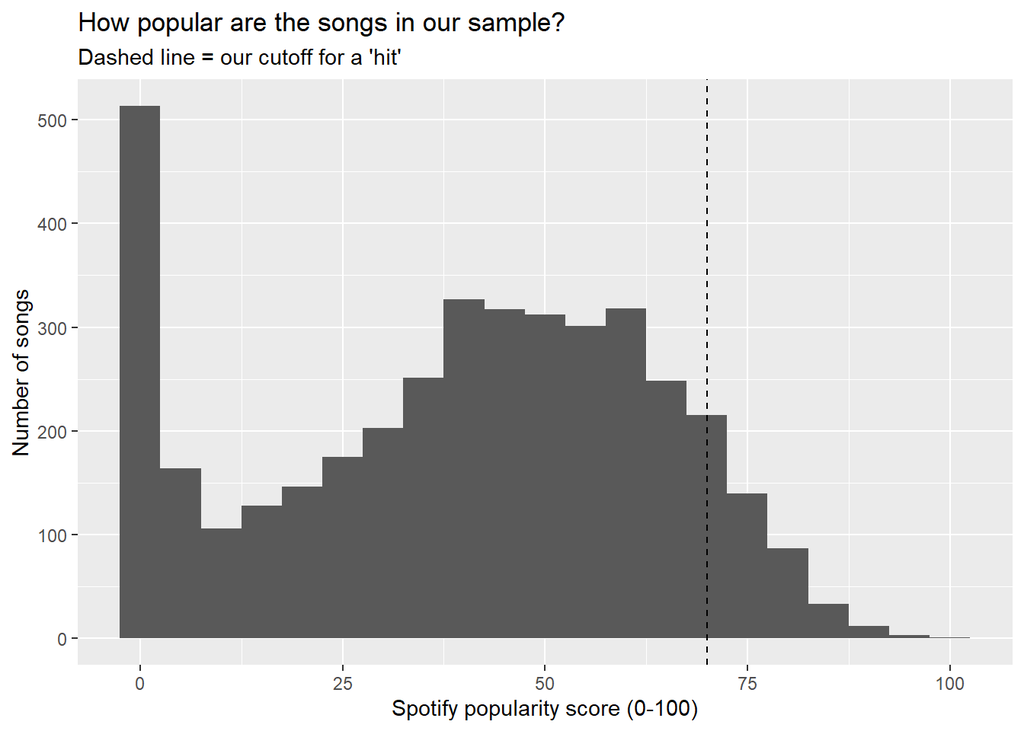

```r
sp %>%
  ggplot(aes(x = track_popularity)) +
  geom_histogram(binwidth = 5) +
  geom_vline(xintercept = 70, linetype = "dashed") +
  labs(x = "Spotify popularity score (0-100)",
       y = "Number of songs",
       title = "How popular are the songs in our sample?",
       subtitle = "Dashed line = our cutoff for a 'hit'")
```

We define a **hit** as a popularity score of 70 or more.

```r
sp <- sp %>%
  mutate(hit = track_popularity >= 70)

sp %>%
  count(hit) %>%
  mutate(share = n / sum(n))
```

```
## # A tibble: 2 × 3
##   hit       n share
##   <lgl> <int> <dbl>
## 1 FALSE  3612 0.903
## 2 TRUE    388 0.097
```

Only about 1 song in 10 is a hit. As with the Fortnite wins, that rarity is going to matter.

## An interactive look

Wrap a normal `ggplot` in `ggplotly()` and it becomes interactive. Hover over a point to see which song it is. Double-click the legend to isolate one group.

```r
p_scatter <- sp %>%
  ggplot(aes(x = energy, y = loudness, color = hit,
             text = paste0(track_name, " (", track_artist, ")",
                           "<br>Popularity: ", track_popularity))) +
  geom_point(alpha = 0.5) +
  labs(x = "Energy", y = "Loudness (dB)", color = "Hit?",
       title = "Do hits sound different from other songs?")

ggplotly(p_scatter, tooltip = "text")
```

[interactive chart not shown]

The `text` aesthetic is only used for the hover label. Hits and non-hits overlap heavily. Keep that overlap in mind: it tells us that no classifier is going to be perfect here.

**PAUSE: everyone should be here. If not, run the next checkpoint.**

# Section 2: The baseline

```r
# CHECKPOINT 2 ------------------------------------------------------------
require(tidyverse)
require(plotly)
sp <- read_rds("https://github.com/jbisbee1/DS1000_F2026/raw/refs/heads/main/data/spotify_songs.rds") %>%
  mutate(hit = track_popularity >= 70)
```

The laziest classifier predicts “not a hit” for every song.

```r
sp %>%
  summarise(share_hit = mean(hit),
            baseline_accuracy = max(mean(hit), 1 - mean(hit)))
```

```
## # A tibble: 1 × 2
##   share_hit baseline_accuracy
##       <dbl>             <dbl>
## 1     0.097             0.903
```

Any model we build has to beat this baseline to be worth anything.

# Section 3: Split into training and test sets

```r
set.seed(123)
inds <- sample(1:nrow(sp),
               size = round(nrow(sp) / 2),
               replace = FALSE)

train <- sp %>% slice(inds)
test <- sp %>% slice(-inds)

nrow(train)
```

```
## [1] 2000
```

```r
nrow(test)
```

```
## [1] 2000
```

```r
test %>%
  count(hit)
```

```
## # A tibble: 2 × 2
##   hit       n
##   <lgl> <int>
## 1 FALSE  1810
## 2 TRUE    190
```

# Section 4: Fit a model and predict on the test set

```r
# CHECKPOINT 4 ------------------------------------------------------------
require(tidyverse)
require(plotly)
sp <- read_rds("https://github.com/jbisbee1/DS1000_F2026/raw/refs/heads/main/data/spotify_songs.rds") %>%
  mutate(hit = track_popularity >= 70)
set.seed(123)
inds <- sample(1:nrow(sp), size = round(nrow(sp) / 2), replace = FALSE)
train <- sp %>% slice(inds)
test <- sp %>% slice(-inds)
```

As in Lecture 14, we use a linear regression with a TRUE/FALSE outcome. The predictors are the audio features and the genre of the playlist the song appears in.

```r
m_full <- lm(hit ~ danceability + energy + loudness + valence +
               acousticness + speechiness + playlist_genre,
             data = train)

summary(m_full)
```

```
##
## Call:
## lm(formula = hit ~ danceability + energy + loudness + valence +
##     acousticness + speechiness + playlist_genre, data = train)
##
## Residuals:
##      Min       1Q   Median       3Q      Max
## -0.27441 -0.12985 -0.08998 -0.03331  1.27861
##
## Coefficients:
##                      Estimate Std. Error t value Pr(>|t|)
## (Intercept)          0.238494   0.074132   3.217 0.001315 **
## danceability         0.136591   0.054557   2.504 0.012372 *
## energy              -0.278414   0.060891  -4.572 5.12e-06 ***
## loudness             0.016356   0.003208   5.099 3.74e-07 ***
## valence              0.006927   0.033541   0.207 0.836413
## acousticness        -0.028401   0.037447  -0.758 0.448279
## speechiness          0.101928   0.073085   1.395 0.163278
## playlist_genrelatin  0.063102   0.025297   2.494 0.012698 *
## playlist_genrepop    0.140707   0.022969   6.126 1.08e-09 ***
## playlist_genrer&b    0.052899   0.025717   2.057 0.039822 *
## playlist_genrerap    0.038796   0.025137   1.543 0.122897
## playlist_genrerock   0.103184   0.026671   3.869 0.000113 ***
## ---
## Signif. codes:  0 '***' 0.001 '**' 0.01 '*' 0.05 '.' 0.1 ' ' 1
##
## Residual standard error: 0.2931 on 1988 degrees of freedom
## Multiple R-squared:  0.0429, Adjusted R-squared:  0.0376
## F-statistic:   8.1 on 11 and 1988 DF,  p-value: 5.478e-14
```

Now predict for the **test** songs, which the model never saw:

```r
test <- test %>%
  mutate(pred_prob = predict(m_full, newdata = test))

test %>%
  select(track_name, track_artist, hit, pred_prob) %>%
  arrange(desc(pred_prob)) %>%
  head(10)
```

```
## # A tibble: 10 × 4
##    track_name       track_artist       hit   pred_prob
##    <chr>            <chr>              <lgl>     <dbl>
##  1 La forêt         Lescop             FALSE     0.286
##  2 Don't Cha        The Pussycat Dolls FALSE     0.279
##  3 Marijuana Breath Adam Jensen        FALSE     0.278
##  4 Slow Hands       Niall Horan        FALSE     0.264
##  5 R.E.M            Ariana Grande      FALSE     0.257
##  6 No Type          Rae Sremmurd       TRUE      0.255
##  7 Twenty One       Greyson Chance     FALSE     0.254
##  8 Seasons          Aso                FALSE     0.253
##  9 Anywhere         Dillon Francis     FALSE     0.250
## 10 Attention        Charlie Puth       TRUE      0.247
```

Check the range of the scores. Before we choose a threshold, we should know what thresholds are even possible.

```r
range(test$pred_prob)
```

```
## [1] -0.2574037  0.2856576
```

The highest score is well below 0.5. What does that mean for a threshold of 0.5?

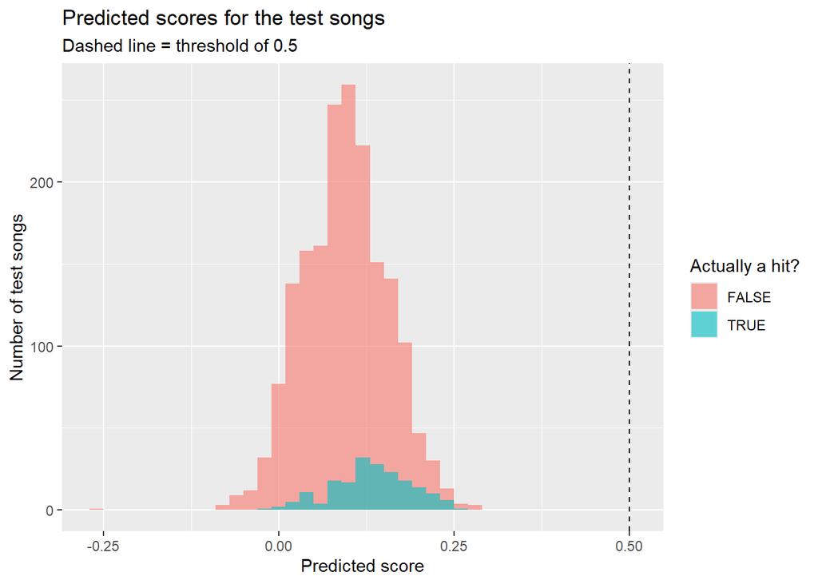

```r
test %>%
  ggplot(aes(x = pred_prob, fill = hit)) +
  geom_histogram(binwidth = 0.02, position = "identity", alpha = 0.6) +
  geom_vline(xintercept = 0.5, linetype = "dashed") +
  labs(x = "Predicted score", y = "Number of test songs",
       fill = "Actually a hit?",
       title = "Predicted scores for the test songs",
       subtitle = "Dashed line = threshold of 0.5")
```

**PAUSE: everyone should be here. If not, run the next checkpoint.**

# Section 5: Sensitivity and specificity at one threshold

```r
# CHECKPOINT 5 ------------------------------------------------------------
require(tidyverse)
require(plotly)
sp <- read_rds("https://github.com/jbisbee1/DS1000_F2026/raw/refs/heads/main/data/spotify_songs.rds") %>%
  mutate(hit = track_popularity >= 70)
set.seed(123)
inds <- sample(1:nrow(sp), size = round(nrow(sp) / 2), replace = FALSE)
train <- sp %>% slice(inds)
test <- sp %>% slice(-inds)
m_full <- lm(hit ~ danceability + energy + loudness + valence +
               acousticness + speechiness + playlist_genre,
             data = train)
test <- test %>% mutate(pred_prob = predict(m_full, newdata = test))
```

Start with the default threshold of 0.5 and the confusion matrix from last class. Remember to use factors and `.drop = FALSE` so empty cells are kept.

```r
test <- test %>%
  mutate(pred_class = pred_prob >= 0.5)

test %>%
  mutate(hit = factor(hit, levels = c(TRUE, FALSE)),
         pred_class = factor(pred_class, levels = c(TRUE, FALSE))) %>%
  count(hit, pred_class, .drop = FALSE)
```

```
## # A tibble: 4 × 3
##   hit   pred_class     n
##   <fct> <fct>      <int>
## 1 TRUE  TRUE           0
## 2 TRUE  FALSE        190
## 3 FALSE TRUE           0
## 4 FALSE FALSE       1810
```

At 0.5 the model never predicts a hit. Its accuracy equals the baseline. Now the two questions from the slides:

- **Sensitivity:** of the songs that actually were hits, what share did we flag as hits?
- **Specificity:** of the songs that actually were not hits, what share did we correctly rule out?

```r
test %>%
  group_by(hit) %>%
  summarise(n_songs = n(),
            share_flagged_as_hit = mean(pred_class))
```

```
## # A tibble: 2 × 3
##   hit   n_songs share_flagged_as_hit
##   <lgl>   <int>                <dbl>
## 1 FALSE    1810                    0
## 2 TRUE      190                    0
```

The row for `hit = TRUE` is the sensitivity. The row for `hit = FALSE` is `1 - specificity`. At 0.5, sensitivity is 0 and specificity is 1. A model that never says “hit” is perfect at ruling out non-hits and useless at finding hits.

Now lower the threshold to 0.15:

```r
test <- test %>%
  mutate(pred_class_15 = pred_prob >= 0.15)

test %>%
  group_by(hit) %>%
  summarise(n_songs = n(),
            share_flagged_as_hit = mean(pred_class_15))
```

```
## # A tibble: 2 × 3
##   hit   n_songs share_flagged_as_hit
##   <lgl>   <int>                <dbl>
## 1 FALSE    1810                0.188
## 2 TRUE      190                0.379
```

```r
test %>%
  summarise(accuracy_50 = mean(pred_class == hit),
            accuracy_15 = mean(pred_class_15 == hit))
```

```
## # A tibble: 1 × 2
##   accuracy_50 accuracy_15
##         <dbl>       <dbl>
## 1       0.905       0.771
```

We now catch some hits, but we also flag many non-hits, and overall accuracy **falls**. Lowering the threshold bought sensitivity at the cost of specificity (and accuracy).

# Section 6: Sweeping the threshold

```r
# CHECKPOINT 6 ------------------------------------------------------------
require(tidyverse)
require(plotly)
sp <- read_rds("https://github.com/jbisbee1/DS1000_F2026/raw/refs/heads/main/data/spotify_songs.rds") %>%
  mutate(hit = track_popularity >= 70)
set.seed(123)
inds <- sample(1:nrow(sp), size = round(nrow(sp) / 2), replace = FALSE)
train <- sp %>% slice(inds)
test <- sp %>% slice(-inds)
m_full <- lm(hit ~ danceability + energy + loudness + valence +
               acousticness + speechiness + playlist_genre,
             data = train)
test <- test %>% mutate(pred_prob = predict(m_full, newdata = test))
```

Instead of picking one threshold, we try many. We write a function that takes the predicted scores, the truth, and a set of thresholds, and returns the confusion matrix counts for each threshold.

```r
sweep_thresholds <- function(probs, truth,
                             thresholds = seq(min(probs), max(probs), length.out = 101)) {
  map_dfr(thresholds, function(t) {
    tibble(threshold = t,
           tp = sum(probs >= t & truth),
           fn = sum(probs < t & truth),
           tn = sum(probs < t & !truth),
           fp = sum(probs >= t & !truth))
  }) %>%
    mutate(sensitivity = tp / (tp + fn),
           specificity = tn / (tn + fp))
}

roc_full <- sweep_thresholds(test$pred_prob, test$hit)

roc_full %>%
  select(threshold, tp, fn, tn, fp, sensitivity, specificity) %>%
  slice(c(1, 25, 50, 75, 101))
```

```
## # A tibble: 5 × 7
##   threshold    tp    fn    tn    fp sensitivity specificity
##       <dbl> <int> <int> <int> <int>       <dbl>       <dbl>
## 1  -0.257     190     0     0  1810       1        0
## 2  -0.127     190     0     1  1809       1        0.000552
## 3   0.00870   188     2   129  1681       0.989    0.0713
## 4   0.144      80   110  1426   384       0.421    0.788
## 5   0.286       0   190  1809     1       0        0.999
```

The thresholds run from the lowest score (everything is called a hit) to the highest score (almost nothing is). Now plot both metrics against the threshold. Hover to read off the exact values at any threshold.

```r
p_tradeoff <- roc_full %>%
  pivot_longer(c(sensitivity, specificity),
               names_to = "metric", values_to = "value") %>%
  ggplot(aes(x = threshold, y = value, color = metric)) +
  geom_line() +
  labs(x = "Threshold", y = "Value", color = "",
       title = "Sensitivity and specificity move in opposite directions")

ggplotly(p_tradeoff)
```

[interactive chart not shown]

There is no threshold that maximizes both at once. Which one we should prefer depends on the cost of each kind of mistake, which is a judgment call and not a statistical one.

## Drag the threshold yourself

This version animates the four cells of the confusion matrix. Drag the slider (or press Play) and watch the counts move.

```r
cells <- roc_full %>%
  mutate(step = round(threshold, 3)) %>%
  select(step, `True positive` = tp, `False negative` = fn,
         `False positive` = fp, `True negative` = tn) %>%
  pivot_longer(-step, names_to = "cell", values_to = "n_songs") %>%
  mutate(cell = factor(cell, levels = c("True positive", "False negative",
                                        "False positive", "True negative")))

plot_ly(cells, x = ~cell, y = ~n_songs, color = ~cell,
        frame = ~step, type = "bar") %>%
  layout(xaxis = list(title = ""),
         yaxis = list(title = "Number of test songs", range = c(0, nrow(test)))) %>%
  animation_slider(currentvalue = list(prefix = "Threshold: "))
```

[interactive chart not shown]

Notice that the true positives and false positives shrink together as the threshold rises. You cannot lower one without lowering the other.

**PAUSE: everyone should be here. If not, run the next checkpoint.**

# Section 7: The ROC curve and AUC

```r
# CHECKPOINT 7 ------------------------------------------------------------
require(tidyverse)
require(plotly)
sp <- read_rds("https://github.com/jbisbee1/DS1000_F2026/raw/refs/heads/main/data/spotify_songs.rds") %>%
  mutate(hit = track_popularity >= 70)
set.seed(123)
inds <- sample(1:nrow(sp), size = round(nrow(sp) / 2), replace = FALSE)
train <- sp %>% slice(inds)
test <- sp %>% slice(-inds)
m_full <- lm(hit ~ danceability + energy + loudness + valence +
               acousticness + speechiness + playlist_genre,
             data = train)
test <- test %>% mutate(pred_prob = predict(m_full, newdata = test))

sweep_thresholds <- function(probs, truth,
                             thresholds = seq(min(probs), max(probs), length.out = 101)) {
  map_dfr(thresholds, function(t) {
    tibble(threshold = t,
           tp = sum(probs >= t & truth),
           fn = sum(probs < t & truth),
           tn = sum(probs < t & !truth),
           fp = sum(probs >= t & !truth))
  }) %>%
    mutate(sensitivity = tp / (tp + fn),
           specificity = tn / (tn + fp))
}
roc_full <- sweep_thresholds(test$pred_prob, test$hit)
```

The **ROC curve** plots the whole tradeoff at once. The x-axis is `1 - specificity` (how often we wrongly flag a non-hit) and the y-axis is sensitivity (how often we correctly catch a hit). Hover over the curve to see which threshold produced each point.

```r
p_roc <- roc_full %>%
  mutate(fpr = 1 - specificity,
         label = paste0("Threshold: ", round(threshold, 3),
                        "<br>Sensitivity: ", round(sensitivity, 3),
                        "<br>Specificity: ", round(specificity, 3))) %>%
  ggplot(aes(x = fpr, y = sensitivity, text = label, group = 1)) +
  geom_line() +
  geom_point(size = 0.8) +
  geom_abline(slope = 1, intercept = 0, linetype = "dashed") +
  labs(x = "1 - specificity", y = "Sensitivity",
       title = "ROC curve for the full model")

ggplotly(p_roc, tooltip = "text")
```

[interactive chart not shown]

The dashed diagonal is what a coin flip would produce. The farther the curve bows up and to the left, the better the classifier separates hits from non-hits.

**AUC** is the area under that curve, a single number between 0.5 (no better than guessing) and 1 (perfect). We compute it with the trapezoid rule:

```r
compute_auc <- function(roc_dat) {
  roc_sorted <- roc_dat %>%
    mutate(fpr = 1 - specificity) %>%
    drop_na(sensitivity, fpr) %>%
    arrange(fpr)
  sum(diff(roc_sorted$fpr) *
        (head(roc_sorted$sensitivity, -1) + tail(roc_sorted$sensitivity, -1)) / 2)
}

auc_full <- compute_auc(roc_full)
auc_full
```

```
## [1] 0.6816953
```

Unlike accuracy, AUC does not depend on a threshold we had to choose.

# Section 8: Your turn

```r
# CHECKPOINT 8 ------------------------------------------------------------
require(tidyverse)
require(plotly)
sp <- read_rds("https://github.com/jbisbee1/DS1000_F2026/raw/refs/heads/main/data/spotify_songs.rds") %>%
  mutate(hit = track_popularity >= 70)

sweep_thresholds <- function(probs, truth,
                             thresholds = seq(min(probs), max(probs), length.out = 101)) {
  map_dfr(thresholds, function(t) {
    tibble(threshold = t,
           tp = sum(probs >= t & truth),
           fn = sum(probs < t & truth),
           tn = sum(probs < t & !truth),
           fp = sum(probs >= t & !truth))
  }) %>%
    mutate(sensitivity = tp / (tp + fn),
           specificity = tn / (tn + fp))
}
compute_auc <- function(roc_dat) {
  roc_sorted <- roc_dat %>%
    mutate(fpr = 1 - specificity) %>%
    drop_na(sensitivity, fpr) %>%
    arrange(fpr)
  sum(diff(roc_sorted$fpr) *
        (head(roc_sorted$sensitivity, -1) + tail(roc_sorted$sensitivity, -1)) / 2)
}

set.seed(123)
inds <- sample(1:nrow(sp), size = round(nrow(sp) / 2), replace = FALSE)
train <- sp %>% slice(inds)
test <- sp %>% slice(-inds)
```

**Claim:** “You only need to know how a song *sounds* to predict a hit. Knowing the genre adds nothing.”

1. Fit a model with only audio features: `hit ~ danceability + energy + loudness + valence + acousticness + speechiness`.
2. Fit the full model from today, which also includes `playlist_genre`.
3. Predict on `test` for both, sweep the thresholds, and compute each AUC.
4. Plot both ROC curves on the same graph. Is the claim supported?

```r
m_audio <- lm(hit ~ danceability + energy + loudness + valence +
                acousticness + speechiness,
              data = train)
m_genre <- lm(hit ~ danceability + energy + loudness + valence +
                acousticness + speechiness + playlist_genre,
              data = train)

roc_audio <- sweep_thresholds(predict(m_audio, newdata = test), test$hit) %>%
  mutate(model = "Audio features only")
roc_genre <- sweep_thresholds(predict(m_genre, newdata = test), test$hit) %>%
  mutate(model = "Audio features + genre")

c(audio_only = compute_auc(roc_audio),
  with_genre = compute_auc(roc_genre))
```

```
## audio_only with_genre
##  0.6339852  0.6816953
```

```r
p_compare <- bind_rows(roc_audio, roc_genre) %>%
  mutate(fpr = 1 - specificity,
         label = paste0(model,
                        "<br>Threshold: ", round(threshold, 3),
                        "<br>Sensitivity: ", round(sensitivity, 3),
                        "<br>Specificity: ", round(specificity, 3))) %>%
  ggplot(aes(x = fpr, y = sensitivity, color = model, text = label, group = model)) +
  geom_line() +
  geom_abline(slope = 1, intercept = 0, linetype = "dashed") +
  labs(x = "1 - specificity", y = "Sensitivity", color = "",
       title = "Do the two models separate hits equally well?")

ggplotly(p_compare, tooltip = "text")
```

[interactive chart not shown]

One test set is one draw of the data. To see whether the gap is stable, we repeat the split many times, as in Lecture 12. We use 25 repeats to keep this fast; the slides use 100.

```r
set.seed(123)
cv_auc <- map_dfr(1:25, function(i) {
  inds_i <- sample(1:nrow(sp), size = round(nrow(sp) / 2), replace = FALSE)
  train_i <- sp %>% slice(inds_i)
  test_i <- sp %>% slice(-inds_i)

  m_audio_i <- lm(hit ~ danceability + energy + loudness + valence +
                    acousticness + speechiness, data = train_i)
  m_genre_i <- lm(hit ~ danceability + energy + loudness + valence +
                    acousticness + speechiness + playlist_genre, data = train_i)

  tibble(sim = i,
         `Audio features only` = compute_auc(sweep_thresholds(predict(m_audio_i, newdata = test_i), test_i$hit)),
         `Audio features + genre` = compute_auc(sweep_thresholds(predict(m_genre_i, newdata = test_i), test_i$hit)))
}) %>%
  pivot_longer(-sim, names_to = "model", values_to = "auc")

cv_auc %>%
  group_by(model) %>%
  summarise(mean_auc = mean(auc))
```

```
## # A tibble: 2 × 2
##   model                  mean_auc
##   <chr>                     <dbl>
## 1 Audio features + genre    0.674
## 2 Audio features only       0.633
```

```r
p_cv <- cv_auc %>%
  ggplot(aes(x = auc, fill = model)) +
  geom_density(alpha = 0.4) +
  labs(x = "AUC on the test half", y = "Density", fill = "",
       title = "AUC across 25 random train/test splits")

ggplotly(p_cv)
```

[interactive chart not shown]

# Aside: which mistake is worse?

The “right” threshold depends on who is asking.

- A **record label scout** wants to find every future hit and does not mind listening to some duds. That favors a **low** threshold (high sensitivity).
- A **radio station** has a few slots and wants every song it plays to land. That favors a **high** threshold (high specificity).

The model is the same. The costs of the two mistakes are different, so the best threshold is different. The statistics tell us what each threshold gives up. They do not tell us which price to pay.

# Summary

1. A classifier’s accuracy at one threshold is a snapshot. Compare it to the baseline first.
2. **Sensitivity** is the share of actual positives we catch. **Specificity** is the share of actual negatives we correctly rule out.
3. Raising the threshold pushes the two in opposite directions. No threshold maximizes both.
4. The **ROC curve** plots the whole tradeoff, and **AUC** summarizes it in one number that does not depend on the threshold.
5. Compare models on held-out data, ideally across many splits, and remember that a better AUC does not tell us what *causes* a hit.